# Layouts with meaningful edge lengths

Installed figures use static projections. To enable 3D rotation and layout selection, render with `options(grip.vignette.interactive = TRUE)` and **ivue** and **rgl** installed.

An edge length specifies a desired traversal cost or separation. It differs from a connection strength, and from the weight assigned to a distance error inside an optimizer. This guide demonstrates the metric choice on a torus and then shows a tree whose lengths are defined without a generating surface.

## The same lengths, two graph metrics

A torus has two periodic directions. The constructor supplies 3D generating coordinates, edges, and Euclidean lengths between adjacent surface points. These lengths define paths on a finite graph, not exact continuous-surface geodesics.

```r
g <- torus.surface.graph(12,8,normalize='none')
hop <- grip(edges=g$edges,n=g$n,edge.weights=g$edge_weights,
  dim=3,metric='hop',seed=1)
weighted <- grip(edges=g$edges,n=g$n,edge.weights=g$edge_weights,
  dim=3,metric='edge_length',length.normalization='none',seed=1)
```

Both fits receive the **same edge lengths**, topology, dimension, and seed. In hop mode, those lengths affect adjacent-edge attractions, while the standard hierarchy and neighborhoods use hop counts. In edge-length mode, sums of the lengths guide the multiscale graph searches. Omitting lengths from the hop call would instead give a purely unweighted baseline, which is a different comparison.

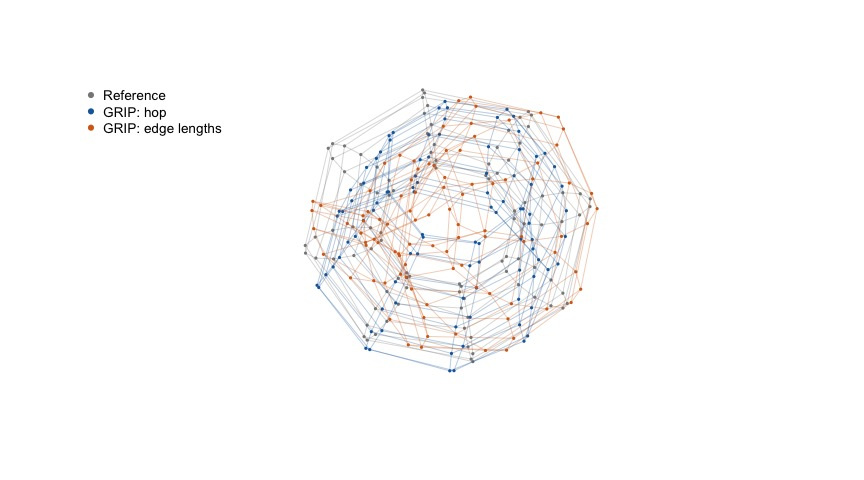

Torus: identical input lengths in both fits. Gray: generating coordinates. Aligned at a common overall size for display. Display multipliers: GRIP: hop 0.0372; GRIP: edge lengths 0.0400 . Scores use original coordinates.

The gray torus shows how the graph was constructed. Graph shortest-path distances need not be realizable as straight-line distances on that surface. The views use matched-vertex rotation/reflection and translation, with a uniform display multiplier to match each fit to the reference’s root-mean-square radius. This separates shape from overall size; the scores below use the original coordinates. A close overlay and low graph-distance stress answer different questions.

```r
fits <- list(Hop=hop,'Edge lengths'=weighted)
scores <- do.call(rbind,lapply(fits,function(z)
  score.layout(z,edges=g$edges,n=g$n,edge.weights=g$edge_weights,
    sample.size.stress=2000L,edge.crossings='never')))
knitr::kable(scores[,c('sampled.stress','edge.length.cv',
                     'sampled.nonedge.sep.ratio')],digits=3)
```

|  | sampled.stress | edge.length.cv | sampled.nonedge.sep.ratio |
| --- | --- | --- | --- |
| Hop | 0.226 | 0.424 | 0.279 |
| Edge lengths | 0.284 | 0.334 | 0.216 |

Both layouts are evaluated against the same weighted graph distances. Unequal drawn edges can be appropriate here: low edge-length variation is not itself the objective for a graph with unequal target lengths.

## Lengths without a reference surface

This binary tree has shorter edges at greater depth and unequal sibling branches. Its lengths are intrinsic inputs; there is no generating 3D shape to recover.

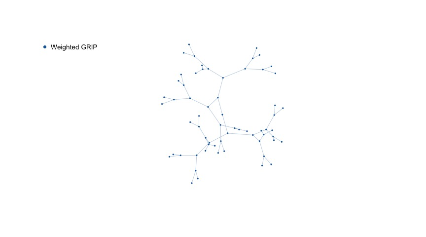

```r
tree <- kary.tree.weighted.graph(k=2,depth=5,depth.decay=.85,
  branch.spread=.2,normalize='none')
tree.coords <- grip(edges=tree$edges,n=tree$n,edge.weights=tree$edge_weights,
  dim=3,metric='edge_length',length.normalization='none',seed=1)
```

An intrinsic weighted tree: shorter branches at greater depth. No generating reference.

## Units, normalization, and stress weighting

`length.normalization='none'` retains the numerical input lengths in the weighted GRIP engine; the default median normalization changes their common scale. It does not make the final coordinates an exact realization of every target length. Check the returned layout with a score appropriate to the task.

Use Choosing and evaluating a layout to compare settings, the graph gallery for other surfaces and recursive constructions, and HMP/U01 for a biological graph with distance-valued edges. Specialized path-based refinements and their scores remain documented in the function overview.